# T-SNE: A Dimensionality Reduction Technique Exploration

Maciej Kuchciak

January 2024

## Introduction

### Overview of dimensionality reduction in unsupervised learning

Dimensionality reduction is a fundamental step in unsupervised learning that enables the analysis and visualization of high-dimensional data. Techniques like t-Distributed Stochastic Neighbor Embedding (t-SNE) help in representation of complex datasets in a lower-dimensional space, preserving significant patterns and relationships from the original data. This process is important for exploring and understanding the structure of data, identifying clusters, and improving the performance of machine learning models.

### Significance of t-SNE

t-SNE, developed by Laurens van der Maaten and Geoffrey Hinton, stands out from dimensionality reduction techniques through its great capability to maintain local data relationships and potential to discover data clusters in an easily understood manner. By converting high-dimensional Euclidean distances between data points into conditional probabilities that represent similarities, t-SNE allows for the visualization of multi-dimensional data in two or three dimensions. This makes t-SNE particularly valuable for datasets like MNIST, where understanding the distribution and separation of digit representations can provide insights into the complexity of the data.

## Methodology

### Selection of dataset

[figure not shown]

MNIST sample of images

### Understanding t-SNE

t-Distributed Stochastic Neighbor Embedding (t-SNE) is a machine learning algorithm designed for visualizing high-dimensional data in a low-dimensional space of two or three dimensions. It is a non-linear dimensionality reduction technique that works well for embedding complex data for visualization purposes.

### Step-by-Step t-SNE Process

#### **Step 1**: Compute Pairwise Similarities in High-Dimensional Space

For each pair of points $x_i$ and $x_j$, compute the conditional probability $p_{j|i}$ that $x_i$ would pick $x_j$ as its neighbor.

$$p_{j|i} = \frac{\exp(-\|x_i - x_j\|^2 / 2\sigma_i^2)}{\sum_{k \neq i}
\exp(-\|x_i - x_k\|^2 / 2\sigma_i^2)}$$

- $x_i, x_j$: Data points in the original high-dimensional space.
- $p_{j|i}$: Conditional probability that point $x_i$ would pick $x_j$ as its neighbor, based on their distance and the density of points around $x_i$.
- $\sigma_i$: The standard deviation of the Gaussian distribution centered on $x_i$, adjusted for each point to maintain a consistent perplexity across the dataset.

#### **Step 2**: Symmetrize the Probability Distribution

Define the joint probability $p_{ij}$ as the symmetrized conditional probabilities.

$$p_{ij} = \frac{p_{j|i} + p_{i|j}}{2N}$$

- $p_{ij}$: The joint probability that points $x_i$ and $x_j$ pick each other as neighbors. It’s symmetrized to ensure that the relationship is mutual, thereby stabilizing the embedding.
- $N$: Total number of points in the dataset, used for normalization.

#### **Step 3**: Compute Pairwise Similarities in Low-Dimensional Space

Use a similar probability distribution with a Student-t distribution in the low-dimensional space.

$$q_{ij} = \frac{(1 + \|y_i - y_j\|^2)^{-1}}{\sum_{k \neq l}(1 + \|y_k -
y_l\|^2)^{-1}}$$

- $y_i, y_j$: Data points in the low-dimensional space, corresponding to $x_i$ and $x_j$.
- $q_{ij}$: Probability that points $y_i$ and $y_j$ are neighbors in the low-dimensional space, using a Student-t distribution to allow for effective separation of clusters by increasing the effective distance between moderately distant points.

#### **Step 4**: Minimize the Kullback–Leibler Divergence

Minimize the Kullback–Leibler divergence between the high-dimensional and low-dimensional probability distributions.

$$KL(P\|Q) = \sum_{i \neq j} p_{ij} \log \frac{p_{ij}}{q_{ij}}$$

- $KL(P||Q)$: The Kullback–Leibler divergence, is a measure of how probability distribution of one probability distribution differs from a second. In the context of t-SNE, it quantifies the difference between the high-dimensional pairwise similarities ($P$) and their low-dimensional counterparts ($Q$).
- $p_{ij}$: The joint probability in the high-dimensional space, indicating the probability that points $x_i$ and $x_j$ are neighbors. It reflects the similarity between points as modeled by a Gaussian distribution in the original space.
- $q_{ij}$: The joint probability in the low-dimensional space, modeling the similarity between points $y_i$ and $y_j$ using a Student-t distribution. The use of the Student-t distribution helps to mitigate the crowding problem by effectively spreading out points that are moderately far apart in the high-dimensional space.
- $\log \frac{p_{ij}}{q_{ij}}$: The logarithm of the ratio of $p_{ij}$ to $q_{ij}$, contributing to the KL divergence calculation. When $p_{ij}$ closely matches $q_{ij}$, their ratio approaches 1, and the logarithm approaches 0, indicating little divergence. Large discrepancies between $p_{ij}$ and $q_{ij}$ contribute positively to the KL divergence, signaling a poor match between the high-dimensional and low-dimensional representations.
- $\sum_{i \neq j}$: The sum over all distinct pairs of points, ensuring that the entire distribution of pairwise similarities is considered in the divergence calculation. This summation accounts for the collective arrangement of all points in the embedding space, emphasizing the preservation of local structures defined by the pairwise probabilities.

The goal of minimizing $KL(P||Q)$ is to adjust the positions of points in the low-dimensional space ($y_i$) such that $Q$ resembles $P$ as closely as possible, thereby ensuring that the t-SNE embeddings faithfully represent the original data’s structure. This optimization process is typically achieved through gradient descent, iteratively adjusting the points’ positions to reduce the KL divergence until a stable, low-dimensional representation of the data is found.

### Application of t-SNE

To apply t-SNE to the MNIST dataset, we first preprocess the data by flattening each image from a 28x28 matrix into a 784-dimensional vector and normalizing the pixel values to the range [0, 1]. The Rtsne package in R is used to perform t-SNE on the flattened dataset, with a focus on hyperparameter tuning to achieve optimal visualization results. The perplexity parameter, a key hyperparameter for t-SNE, is set to 30, and the algorithm is allowed to run for 1000 iterations to ensure convergence (for now, the optimization will be done later on).

```r
# Flatten the images to a 2D matrix where each row is an image
train_images_flat <- array_reshape(train_images, c(dim(train_images)[1], dim(train_images)[2] * dim(train_images)[3]))

# Normalize the pixel values to [0, 1]
train_images_flat <- train_images_flat / 255

# Apply t-SNE with a selected perplexity and maximum iterations
tsne_results_p30_i1000 <- Rtsne(train_images_flat, dims = 2, perplexity = 30, verbose = TRUE, max_iter = 1000)
```

```
## Performing PCA
## Read the 60000 x 50 data matrix successfully!
## OpenMP is working. 1 threads.
## Using no_dims = 2, perplexity = 30.000000, and theta = 0.500000
## Computing input similarities...
## Building tree...
##  - point 10000 of 60000
##  - point 20000 of 60000
##  - point 30000 of 60000
##  - point 40000 of 60000
##  - point 50000 of 60000
##  - point 60000 of 60000
## Done in 375.72 seconds (sparsity = 0.002086)!
## Learning embedding...
## Iteration 50: error is 118.896811 (50 iterations in 13.39 seconds)
## Iteration 100: error is 118.896811 (50 iterations in 14.82 seconds)
## Iteration 150: error is 118.892813 (50 iterations in 14.98 seconds)
## Iteration 200: error is 109.521719 (50 iterations in 12.53 seconds)
## Iteration 250: error is 103.548045 (50 iterations in 14.05 seconds)
## Iteration 300: error is 4.921023 (50 iterations in 12.55 seconds)
## Iteration 350: error is 4.512190 (50 iterations in 11.44 seconds)
## Iteration 400: error is 4.269992 (50 iterations in 11.45 seconds)
## Iteration 450: error is 4.096157 (50 iterations in 11.56 seconds)
## Iteration 500: error is 3.961477 (50 iterations in 11.47 seconds)
## Iteration 550: error is 3.852517 (50 iterations in 11.64 seconds)
## Iteration 600: error is 3.761633 (50 iterations in 11.79 seconds)
## Iteration 650: error is 3.684040 (50 iterations in 12.03 seconds)
## Iteration 700: error is 3.616261 (50 iterations in 11.65 seconds)
## Iteration 750: error is 3.556745 (50 iterations in 11.59 seconds)
## Iteration 800: error is 3.504050 (50 iterations in 11.54 seconds)
## Iteration 850: error is 3.456746 (50 iterations in 11.74 seconds)
## Iteration 900: error is 3.413664 (50 iterations in 11.48 seconds)
## Iteration 950: error is 3.374273 (50 iterations in 11.81 seconds)
## Iteration 1000: error is 3.337869 (50 iterations in 11.52 seconds)
## Fitting performed in 245.04 seconds.
```

```r
dim(train_images)
```

```
## [1] 60000    28    28
```

Additional information, interpreting comments and why PCA?

**Principal Component Analysis (PCA)** is a dimensionality reduction technique that linearly transforms the original data into a new coordinate system, where the greatest variances by any projection of the data come to lie on the first coordinates (called principal components). The key reasons for performing PCA before t-SNE are:

*Dimensionality Reduction*: PCA reduces the dimensionality of the data, focusing on the components that capture the most variance in the data. This reduction is beneficial because t-SNE is computationally expensive and can be slow on very high-dimensional data. By reducing the dimensionality first, t-SNE can run more efficiently.

*Noise Reduction*: PCA can help remove noise by discarding components that capture little variance, which might represent random fluctuations in the data. This cleaner, more concise representation of the data can lead to better embeddings from t-SNE.

*Improved Stability*: Starting t-SNE with data that’s already been somewhat simplified (but still represents the main structures) can lead to more stable and meaningful low-dimensional representations.

Sparsity of 0.002086

*Efficiency*: From a computational standpoint, a sparsity of 0.002086 is beneficial because it means the algorithm can efficiently store and process the similarity matrix, taking advantage of sparse matrix techniques to speed up calculations and reduce memory usage.

*Data Structure*: This level of sparsity suggests that, in the high-dimensional space, most data points are not closely related to most other points, at least within the context of the Gaussian kernels used by t-SNE. It’s a typical scenario for high-dimensional data, where only nearby points (in terms of Euclidean distance) contribute significantly to each other’s local similarity measure.

In the context of using t-SNE for dimensionality reduction and visualization, a sparsity value of 0.002086 is typical for high-dimensional datasets and reflects the efficient computational strategy used by the algorithm.

#### Hyperparameter Tuning in t-SNE

There are only few parameters to hypertune in t-SNE, but they are very important and have great influnce on technique.

**Perplexity**: Perplexity is a measure of the effective number of neighbors each point considers in its local neighborhood. It’s one of the most influential hyperparameters in t-SNE and directly affects the balance between emphasizing local versus global structure in the data. Perplexity impacts how t-SNE views and emphasizes the relationships between points. A low perplexity focuses on very local structure, potentially missing broader patterns.

In contrast, a high perplexity tries to preserve global relationships, which might overlook local connections.

*Tuning Guidance*: The optimal perplexity depends on the dataset size and its intrinsic dimensionality. While values between 5 and 50 are common recommendations, experimentation is key. Larger datasets might require higher perplexity values. It’s advisable to try a range of values to see which offers the best balance for specific data. (It may take a huge amount of time to optimize and check, especially taking into consideration the stability of parameters)

**Number of Iterations**:The number of iterations determines how long the t-SNE algorithm runs to minimize the Kullback–Leibler divergence between the high-dimensional and low-dimensional representations of the data. This process is crucial for achieving a stable and meaningful embedding.

Adequate iterations allow the t-SNE algorithm to converge to a solution that accurately reflects the data’s structure. Too few iterations might leave the algorithm before it has adequately separated clusters or uncovered the data’s intrinsic patterns.

*Tuning Guidance*: Start with a default (e.g., 1000 iterations) and increase if you observe that the embeddings haven’t stabilized (i.e., the plot changes significantly with more iterations). The goal is to find the lowest number of iterations that consistently yields a stable embedding, indicating convergence.

**Theta (Barnes-Hut t-SNE)**:Theta is specific to the Barnes-Hut approximation of t-SNE, a speedup that makes the algorithm feasible for larger datasets. It controls the trade-off between speed and accuracy in this approximation. A lower theta value means the algorithm will use a more accurate but slower approximation to calculate the interactions between points. A higher theta speeds up the computation but at the cost of some accuracy.

*Tuning Guidance*: The default value of 0.5 is often a good balance for many datasets, offering a reasonable compromise between speed and fidelity. For very large datasets or when computational resources are limited, you might consider increasing theta. Conversely, if achieving the highest possible accuracy in your embeddings is paramount and computational resources allow, you might experiment with reducing theta.

In summary, tuning perplexity, the number of iterations, and theta in t-SNE is a balancing act between preserving local versus global data structures, achieving computational efficiency, and ensuring the stability and accuracy of the embeddings. Systematic experimentation, guided by visual and quantitative assessments, is the best approach to finding the optimal settings for your specific dataset and analysis goals.

Below are few example of how perplexity and number of iterations changes its behaviour:

One thing to mention before as it applies to every graph:

*Distinct Clusters*: The visualization displays distinct clusters of data points, each representing one of the ten digit classes (0 through 9) in the MNIST dataset. These clusters are color-coded for clarity.

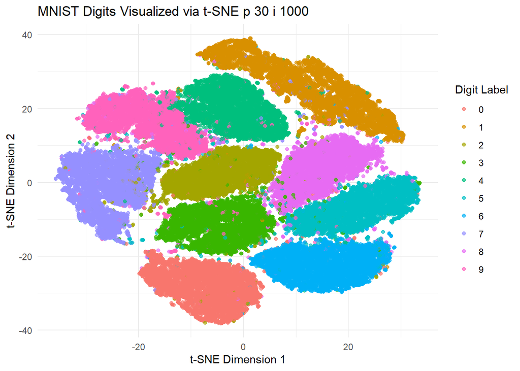

```r
library(ggplot2)

df_tsne <- data.frame(X = tsne_results_p30_i1000$Y[,1], Y = tsne_results_p30_i1000$Y[,2], Digit = as.factor(train_labels))
ggplot(df_tsne, aes(x = X, y = Y, color = Digit)) +
  geom_point(alpha = 0.7) +
  theme_minimal() +
  labs(title = "MNIST Digits Visualized via t-SNE p 30 i 1000", x = "t-SNE Dimension 1", y = "t-SNE Dimension 2", color = "Digit Label")
```

Graph for perplexity = 30 and iterations = 1000

*Cluster Separation*: Some clusters appear well-separated from others, indicating that t-SNE has effectively captured differences between these digit classes. For example, the cluster representing the digit ‘0’ is quite distinct and separate from the others.

*Overlapping Regions*: There are regions where clusters overlap or are close to each other. This overlap may suggest similarities in the way certain digits are written or structural similarities between certain numbers. For instance, digits such as ‘4’ and ‘9’ or ‘3’ and ‘5’ often have visual similarities that can cause overlap in the reduced dimensionality space.

*Noise and Outliers*: The presence of points outside the main clusters, or between clusters, could represent digits that are atypical in their written form, or they could result from noise in the data.

*Data Density*: The density of the clusters may vary, with some clusters appearing more dense, suggesting a higher consistency in how those digits are written, while others are more sparse, indicating more variation in writing style within those digit classes.

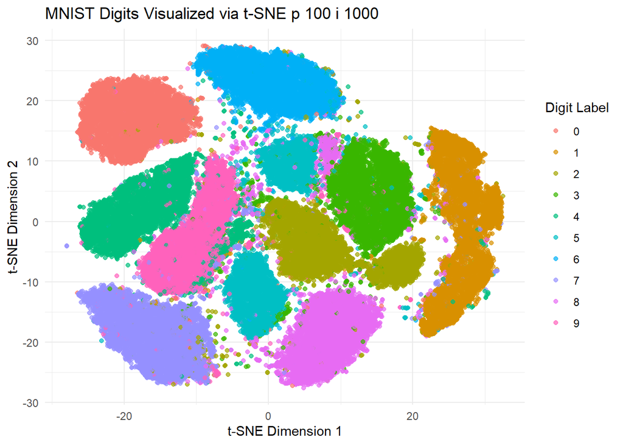

Interpretation of the t-SNE Visualization with Perplexity 100 and iterations of 1000

*Cluster Overlap*: Compared to the previous visualization with a perplexity of 30, there seems to be more overlap between clusters. This might be an indication that the higher perplexity value is causing the algorithm to consider more global aspects of the data, potentially at the expense of local neighborhood preservation.

*Spread of Clusters*: The clusters are more spread out across the plot, which can be a result of the higher perplexity leading to a broader view of neighborhood relationships. Each point is considering more points as its neighbors, which can lead to a less tight clustering.

*Cluster Dispersio*n: The individual clusters appear more dispersed. For example, the clusters for digits ‘3’, ‘5’, and ‘8’ are not as compact as seen with lower perplexity, which could indicate a loss of detail in the local structure of the data.

*Potential Misclassification*: With increased overlap, there’s a higher likelihood that a supervised learning model may misclassify digits, particularly those that reside in overlapping regions.

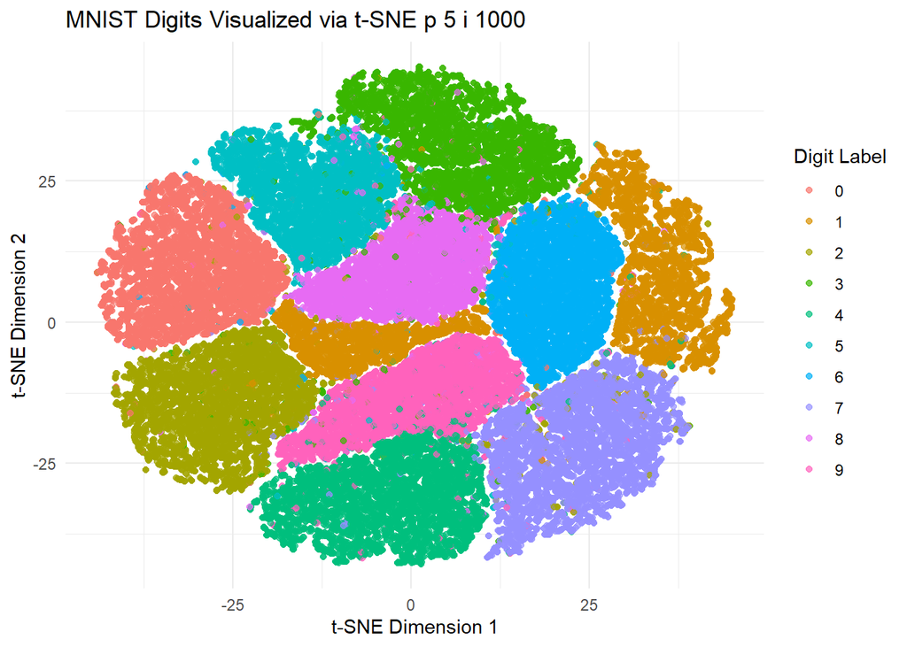

Interpretation of the t-SNE Visualization with Perplexity 5 and iterations of 1000

*Compact Clusters*: The clusters appear more compact and tightly formed compared to those with higher perplexity values. This suggests that a lower perplexity emphasizes local structures and relationships more strongly, causing points to cluster closely around their nearest neighbors.

*Isolated Outliers*: With a lower perplexity, t-SNE tends to create more isolated outliers or small subclusters. This can occur when there are variations within a digit class that are distinct from the main body of that class, causing those points to separate out.

*Potential Overfitting*: A very low perplexity might cause the model to overfit to noise or anomalies in the data, as it might interpret these as meaningful local structures. This can sometimes result in an embedding that captures noise as if it were a significant structure.

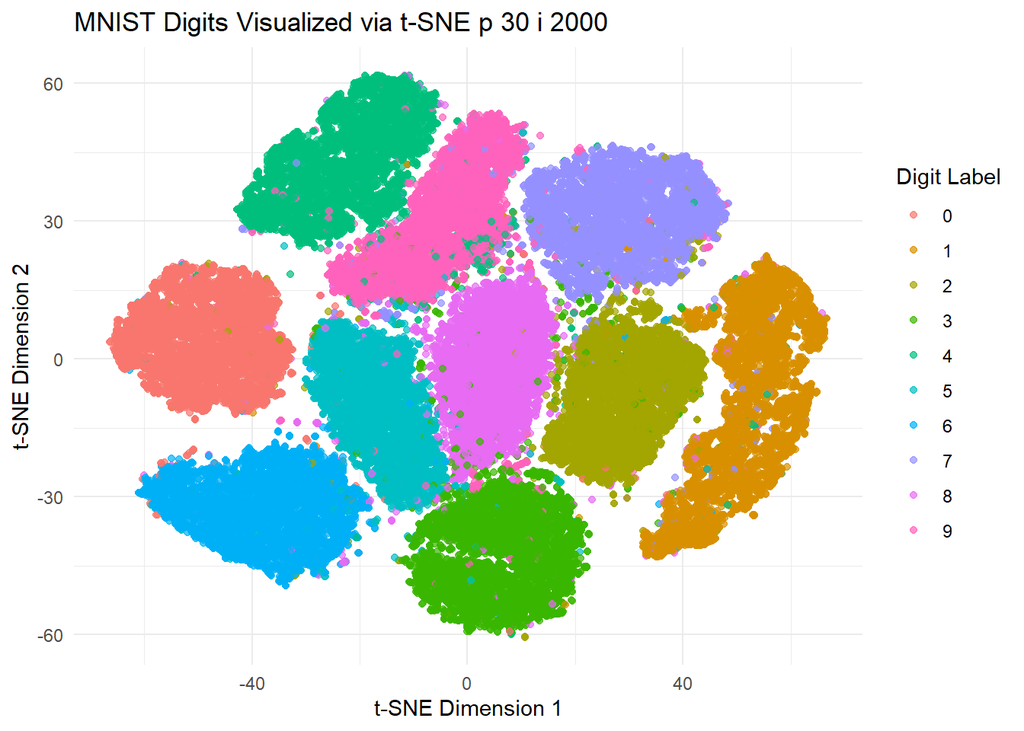

Interpretation of the t-SNE Visualization with Perplexity 30 and Iterations 2000

*Well-Formed Clusters*: The clusters for each digit appear well-formed and mostly distinct from one another. This indicates that t-SNE with these parameters is effectively capturing the local groupings within the data.

*Cluster Separation*: The separation between clusters is clear for many of the digits, suggesting that the chosen perplexity and higher iteration count are enabling the algorithm to find a stable and meaningful low-dimensional representation of the data.

*Consistent Shapes*: Compared to the previous visualization with the same perplexity but fewer iterations (1000), the clusters may appear more consistent in shape and spread. This could be a result of the algorithm having more iterations to refine the positions of each point in the space, leading to a more accurate depiction of the data’s structure.

*Noise and Overlap*: There is some noise and overlap between clusters, which is expected given the complexity of the MNIST dataset and the natural variability in how digits are written. However, the overlap does not seem excessive, and the clusters are still identifiable.

*Outliers*: There are still a few outliers and points that reside between clusters, possibly representing digits that are written in an atypical style or digits that share features with multiple categories.

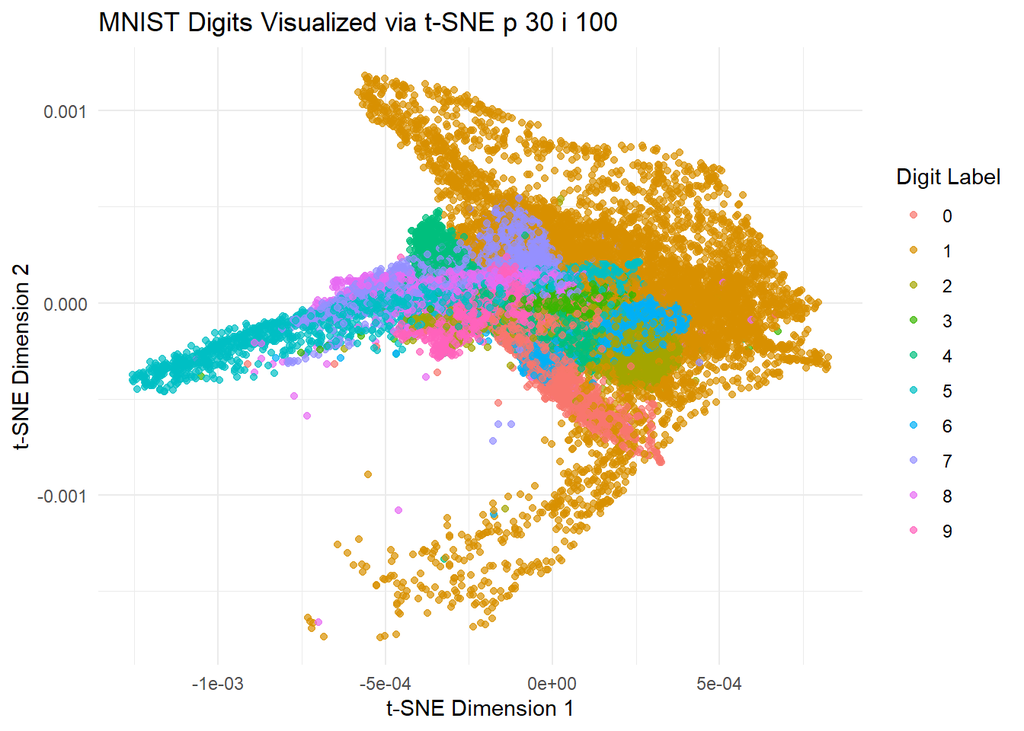

Interpretation of the t-SNE Visualization with Perplexity 30 and Iterations 100

*Underdeveloped Clusters*: The clusters appear less distinct and less separated from one another. This is indicative of an under-optimized t-SNE process where the algorithm has not run long enough to clearly distinguish the digit classes.

*Lack of Stability*: With only 100 iterations, the t-SNE algorithm is likely to be far from converging to a stable solution. This can result in high variability in the output; running the algorithm again with the same parameters could produce a noticeably different plot.

*Potential for Misinterpretation*: Due to the underdeveloped nature of the clusters, relying on this visualization for insights could be misleading. It does not yet represent meaningful relationships within the data accurately.

*Scale of Axes*: The axes’ scales are much smaller than in visualizations with more iterations, indicating that the data points have not been spread out as much. This compact representation can hide nuances and make it difficult to discern the structure of the data.

#### Summary

The baseline setting (perplexity 30, iterations 1000) is effective for MNIST, providing a good starting point for visualization. Increasing perplexity can sometimes merge clusters that should be distinct, indicating that the chosen perplexity may be too high for preserving the local structure of MNIST.

Decreasing perplexity may lead to over-emphasizing local data variance, potentially overfitting to noise and resulting in more fragmented clusters.

Increasing iterations generally improves the stability and clarity of the visualization, as long as the perplexity is appropriate for the data’s structure.

Decreasing iterations below a certain threshold results in an unstable and unclear visualization, underscoring the need for a sufficient number of iterations for the t-SNE algorithm to converge.

## Technical Insights

### Distance Preservation in t-SNE

t-SNE excels at preserving local distances between data points, making it particularly adept at uncovering the local structure of high-dimensional data. By mapping similar data points to nearby points in the low-dimensional space and dissimilar points to distant points, t-SNE facilitates the visualization of clusters and patterns that are difficult to discern in the original high-dimensional space.

### Understanding the Cost Function: Kullback–Leibler Divergence

The core of t-SNE’s effectiveness lies in its cost function, the Kullback–Leibler (KL) divergence, which measures the difference between two probability distributions. t-SNE minimizes the KL divergence between the probability distribution of pairs in the high-dimensional space and the corresponding distribution in the low-dimensional space. This process ensures that the low-dimensional embedding reflects the similarities between points as accurately as possible, given the dimensional reduction.

The KL divergence value gives you an idea of how well the low-dimensional representation approximates the high-dimensional data’s probability distribution. Lower values indicate a closer approximation, but it’s essential to balance this with visual inspection of the embedding to ensure meaningful cluster separation and data representation.

[output not shown]

The KL divergence is a relative measure, meaning its interpretation depends on the context of given specific dataset and the dimensional reduction task at hand. A value of 3.34 indicates that there is some divergence between the high-dimensional and low-dimensional distributions, as a perfectly preserved structure would result in a KL divergence of 0. A KL divergence of 3.34 suggests a reasonably good fit between the two distributions, implying that the low-dimensional embedding captures a significant amount of the high-dimensional data’s structure.

### Scaling and Optimization Challenges

Despite its advantages, t-SNE faces scalability issues. The complexity of the algorithm increases significantly with the size of the dataset, making it challenging to apply t-SNE directly to very large datasets. Various optimization strategies, such as the Barnes-Hut approximation, have been developed to address these challenges, allowing t-SNE to be more computationally efficient while somewhat sacrificing accuracy.

## Practical Application Tips

### Data Preprocessing for t-SNE

Effective data preprocessing is crucial for achieving meaningful t-SNE embeddings. Standard practices include normalizing or standardizing the data to make sure that features do not dominate the distance calculations. Additionally, reducing the dimensionality of the data using PCA, as earlier said before applying t-SNE, can significantly improve computational efficiency and sometimes even the quality of the embedding.

### Choosing Hyperparameters for t-SNE

The choice of hyperparameters, particularly perplexity and the number of iterations, has a substantial impact on the results of t-SNE. Perplexity should be chosen based on the density and size of the dataset, with values between 5 and 50 typically recommended. The number of iterations should be sufficient for the algorithm to converge, often set to at least 1000. However, these values may need adjustment based on specific dataset characteristics and the computational resources available.

## Challenges and Limitations of t-SNE

t-SNE (t-Distributed Stochastic Neighbor Embedding) is a powerful tool for visualizing high-dimensional data by projecting it into a lower-dimensional space (typically two or three dimensions). While t-SNE has been widely adopted for its ability to reveal intricate structures and clusters within complex datasets, it also comes with several challenges and limitations that users should be aware of. Understanding these can help in interpreting t-SNE plots more accurately and guide better decision-making in data analysis and machine learning projects. Some of them are:

**Sensitivity to Hyperparameters**

**Non-convexity of the Cost Function** The cost function minimized by t-SNE is non-convex, leading to potential variance in results across different runs, especially with different initializations or slight changes in hyperparameters. This can make the interpretation of results somewhat subjective and potentially inconsistent.

**Interpretation Challenges** t-SNE is excellent at revealing local structures and clusters but does not preserve global distances well. This means that while clusters are meaningful, the distance between clusters might not be. It’s a mistake to interpret the absolute or relative positioning of clusters in t-SNE plots as indicative of their real-world similarity or dissimilarity. The algorithm tends to expand dense clusters and contract sparse ones, which can sometimes exaggerate separations between groups.

**Scalability and Computational Efficiency** t-SNE can be computationally intensive, particularly on large datasets. The Barnes-Hut approximation improves efficiency by approximating long-range interactions and reducing complexity, but scalability remains a challenge for very large datasets.

**The Crowding Problem and Dimensionality Curse** The “crowding problem” describes a situation where, in reducing dimensions, t-SNE tends to squeeze together points that are not necessarily close in the high-dimensional space. This is related to the curse of dimensionality, where distances in high-dimensional spaces become less meaningful, making it hard for any low-dimensional representation to perfectly capture high-dimensional distances.

**Difficulty in Reproducing Results** Due to its stochastic nature and sensitivity to hyperparameters, reproducing t-SNE results can be difficult without careful documentation of parameter settings and random seeds.

## Conclusion

Dimensionality reduction techniques like t-SNE are essential for simplifying high-dimensional data, allowing researchers and analysts to visualize and understand complex data structures effectively. By carefully pre-processing and selecting appropriate hyperparameters, t-SNE can transform large datasets into more manageable two- or three-dimensional representations. This helps in revealing underlying patterns and relationships. However, it is important to keep in mind the limitations of dimensionality reduction methods while interpreting these visualizations. To obtain a comprehensive understanding of the dataset, it is also necessary to use other analytical tools alongside t-SNE.

In conclusion, t-SNE is a powerful tool in the dimensionality reduction wide range of tools, which can aid significantly in exploratory data analysis.